# English Premier League Stats (2021-2025)

Mike May, Jessica Vescera, Melina Rodriguez, Frank Zawacki

2026-03-24

Introduction: This project explores match performance in the English Premier League from 2021 to 2024. The goal is to analyze home field advantage, team performance metrics, and match outcomes using descriptive statistics and visualizations.

##Load Data

##Fix Column Names

```r
#Use first row as column names
colnames(data) <- data[1, ]

#Remove first row from dataset
data <- data[-1, ]

#Reset row names
rownames(data) <- NULL

# Clean column names
names(data) <- make.names(names(data))

# Check updated structure
str(data)
```

```
## 'data.frame':    1140 obs. of  40 variables:
##  $ date            : chr  "28th May 2023" "28th May 2023" "28th May 2023" "28th May 2023" ...
##  $ clock           : chr  "4:30pm" "4:30pm" "4:30pm" "4:30pm" ...
##  $ stadium         : chr  "Emirates Stadium" "Villa Park" "Gtech Community Stadium" "Stamford Bridge" ...
##  $ class           : chr  "h" "h" "h" "d" ...
##  $ attendance      : chr  "60,095" "42,212" "17,120" "40,130" ...
##  $ Home.Team       : chr  "2" "7" "9" "12" ...
##  $ Goals.Home      : chr  "5" "2" "1" "1" ...
##  $ Away.Team       : chr  "13" "6" "1" "4" ...
##  $ Away.Goals      : chr  "0" "1" "0" "1" ...
##  $ home_possessions: chr  "51" "40.3" "34.4" "64.4" ...
##  $ away_possessions: chr  "49" "59.7" "65.6" "35.6" ...
##  $ home_shots      : chr  "14" "12" "11" "22" ...
##  $ away_shots      : chr  "6" "8" "17" "13" ...
##  $ home_on         : chr  "8" "5" "4" "5" ...
```

[output cut: 26 more lines]

#Convert Data Types

```r
# Convert key columns to numeric
data$Goals.Home <- as.numeric(data$Goals.Home)
data$Away.Goals <- as.numeric(data$Away.Goals)
data$home_shots <- as.numeric(data$home_shots)
data$away_shots <- as.numeric(data$away_shots)
data$home_possessions <- as.numeric(data$home_possessions)
data$away_possessions <- as.numeric(data$away_possessions)

# Fix attendance (remove commas, then convert)
data$attendance <- as.numeric(gsub(",", "", data$attendance))
```

##Create Match Outcome Variables

```
##
## Away Win     Draw Home Win
##      391      257      492
```

##Home Vs Away Win Percentage

```r
# Count results
result_counts <- table(data$result)

# Convert to percentages
result_percent <- prop.table(result_counts) * 100

# Print results
print(result_counts)
```

```
##
## Away Win     Draw Home Win
##      391      257      492
```

```r
print(result_percent)
```

```
##
## Away Win     Draw Home Win
## 34.29825 22.54386 43.15789
```

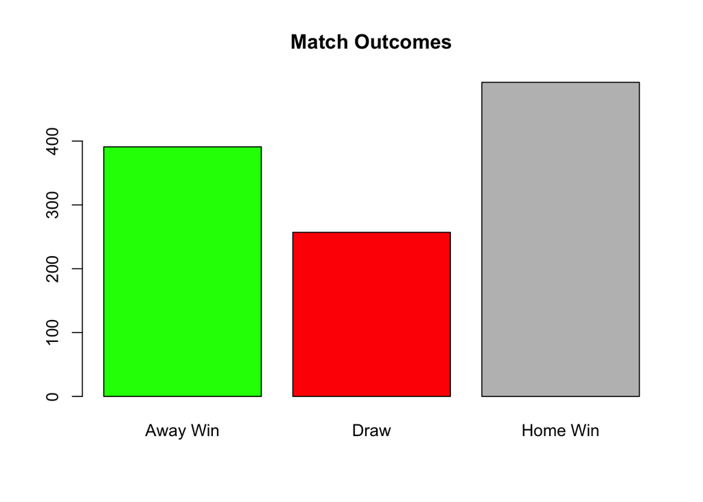

```r
barplot(table(data$result),
        main = "Match Outcomes",
        col = c("green", "red", "gray"))
```

Interpretation:

The bar chart shows the distribution of match outcomes across the dataset. Home wins appear to occur more frequently than away wins and draws, which suggests a potential home-field advantage in the Premier League during this period. Away wins are still fairly common, indicating that away teams remain competitive, but they do not occur as often as home wins. Draws are the least frequent outcome, showing that most matches tend to produce a clear winner rather than ending evenly. Overall, this pattern supports the idea that playing at home may provide a slight advantage, but matches are still relatively competitive across all outcomes.

##Goal Analysis

```r
mean(data$Goals.Home, na.rm = TRUE)
```

```
## [1] 1.502632
```

```r
mean(data$Away.Goals, na.rm = TRUE)
```

```
## [1] 1.290351
```

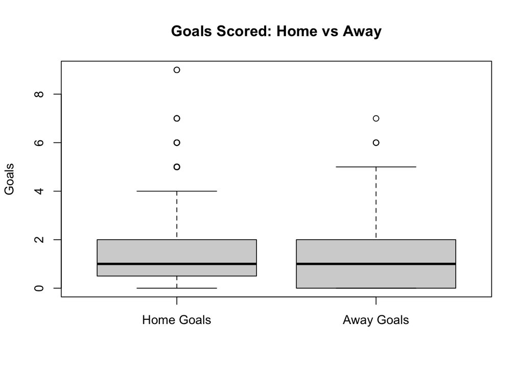

```r
boxplot(data$Goals.Home, data$Away.Goals,
        names = c("Home Goals", "Away Goals"),
        main = "Goals Scored: Home vs Away",
        ylab = "Goals")
```

Interpretation:

This boxplot compares goals scored at home vs away. Home and away teams look pretty similar overall. The median number of goals is close for both, but home teams appear to score slightly more on average. The spread (IQR) is also similar, meaning the variability in goals is about the same in both cases. Both groups have a few outliers, especially on the higher end, showing that in some matches teams scored a lot more goals than usual. However, these are rare and don’t change the overall pattern much. Overall, the chart suggests a slight home advantage, but not a huge difference between home and away goal scoring.

##Shots vs Goals

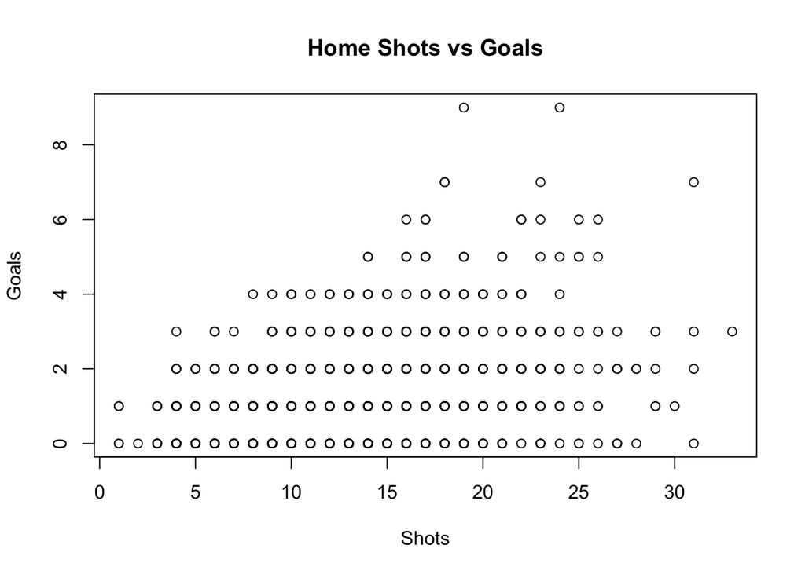

```r
plot(data$home_shots, data$Goals.Home,
     main = "Home Shots vs Goals",
     xlab = "Shots",
     ylab = "Goals")
```

Interpretation: There’s a general upward trend showing that as home teams take more shots, they tend to score more goals. However, the spread of points shows that more shots don’t always guarantee more goals, so efficiency still matters.

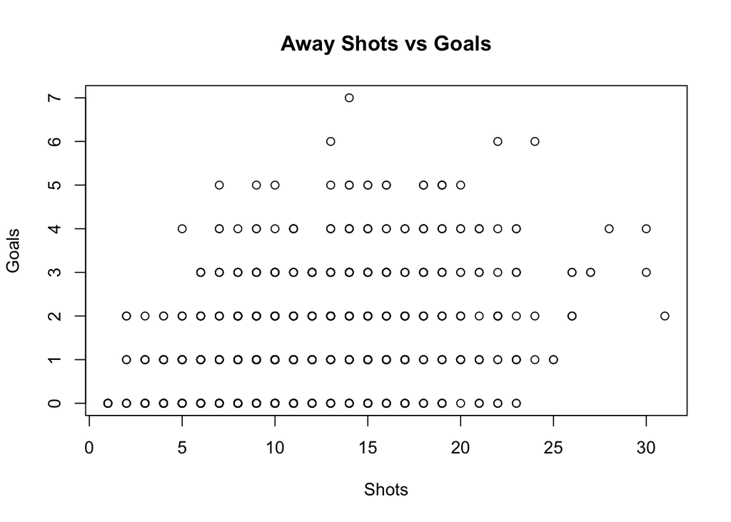

```r
plot(data$away_shots, data$Away.Goals,
     main = "Away Shots vs Goals",
     xlab = "Shots",
     ylab = "Goals")
```

Interpretation: Away teams also show a positive relationship between shots and goals, but the pattern looks slightly more spread out. This suggests that away teams may be a bit less consistent in converting chances compared to home teams.

##Possession Analysis

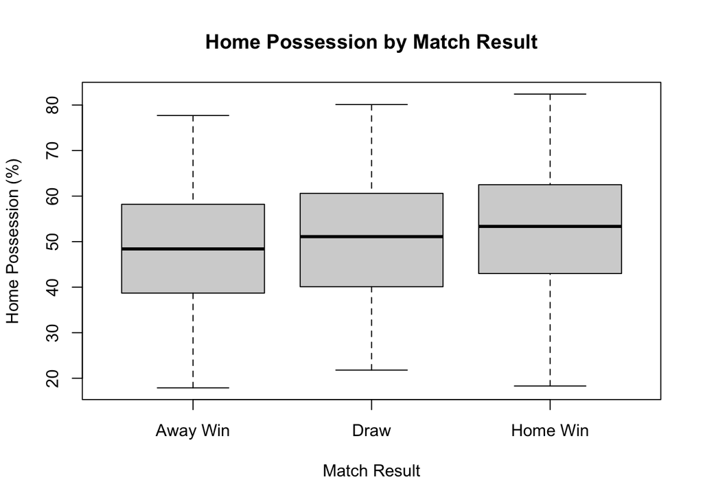

```r
boxplot(home_possessions ~ result, data = data,
        main = "Home Possession by Match Result",
        xlab = "Match Result",
        ylab = "Home Possession (%)")
```

Interpretation: Home teams tend to have higher possession in games they win compared to games they lose. However, the overlap between groups shows that possession alone doesn’t determine the outcome, and other factors like finishing and defense also play a role.

##Random Forest Model

```r
# Load package
library(randomForest)
# Make sure result is a factor
data$result <- as.factor(data$result)

# Select variables
model_data <- data[, c("result",
                       "home_shots", "away_shots",
                       "home_possessions", "away_possessions")]

# Convert to numeric (safety)
model_data$home_shots <- as.numeric(model_data$home_shots)
model_data$away_shots <- as.numeric(model_data$away_shots)
model_data$home_possessions <- as.numeric(model_data$home_possessions)
model_data$away_possessions <- as.numeric(model_data$away_possessions)

# Remove missing values
model_data <- na.omit(model_data)

# Create "advantage" variables
model_data$shot_diff <- model_data$home_shots - model_data$away_shots
model_data$possession_diff <- model_data$home_possessions - model_data$away_possessions

# Set seed for reproducibility
set.seed(123)

# Train/test split (70/30)
train_index <- sample(1:nrow(model_data), 0.7 * nrow(model_data))

train_data <- model_data[train_index, ]
test_data  <- model_data[-train_index, ]

# Train Random Forest model
rf_model <- randomForest(result ~ ., data = train_data, ntree = 100)

# Model summary
print(rf_model)
```

```
##
## Call:
##  randomForest(formula = result ~ ., data = train_data, ntree = 100)
##                Type of random forest: classification
##                      Number of trees: 100
## No. of variables tried at each split: 2
##
##         OOB estimate of  error rate: 52.63%
## Confusion matrix:
##          Away Win Draw Home Win class.error
## Away Win      142   35      102   0.4910394
## Draw           61   26       84   0.8479532
## Home Win       94   44      210   0.3965517
```

```r
# Predictions
predictions <- predict(rf_model, test_data)

# Confusion matrix
table(Predicted = predictions, Actual = test_data$result)
```

```
##           Actual
## Predicted  Away Win Draw Home Win
##   Away Win       60   38       40
##   Draw           10    7       19
##   Home Win       42   41       85
```

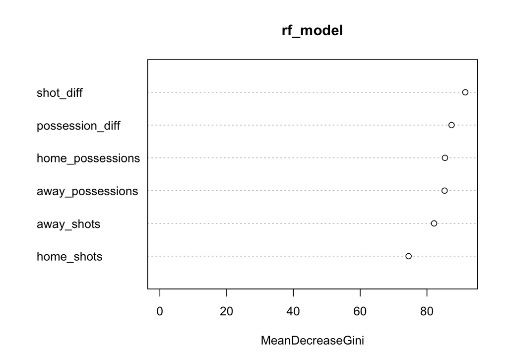

```r
# Variable importance
varImpPlot(rf_model)
```